# Import, Inspect, Clean and Explore a Dataset

## Calculate and plot 7-day moving averages of deaths

This time we’re going to calculate the 7 day rolling average, much like the [Financial Times](https://ig.ft.com/coronavirus-chart/?areas=usa&areas=gbr&areasRegional=usny&areasRegional=usca&areasRegional=usfl&areasRegional=ustx&cumulative=0&logScale=1&perMillion=0&values=deaths) does

```r
df_deaths_rolling_mean <- df_deaths %>%   # this is a new object
  group_by(state) %>%
  mutate(
    #calculate 3-day rolling average
    death3 = zoo::rollmean(daily_deaths, k=3, fill = NA),
    cases3 = zoo::rollmean(daily_cases, k=3, fill = NA),

    #calculate 5-day rolling average
    death5 = zoo::rollmean(daily_deaths, k=5, fill = NA),
    cases5 = zoo::rollmean(daily_cases, k=5, fill = NA),

    #calculate 7-day rolling average
    death7 = zoo::rollmean(daily_deaths, k=7, fill = NA),
    cases7 = zoo::rollmean(daily_cases, k=7, fill = NA)) %>%
    filter(death7 >= 3) %>%
    mutate(days = 1:n()) %>%
    mutate(label = if_else(days == max(days),
                           state,
                           NA_character_)) %>%
    ungroup() %>%
    filter(state %in% c("New York", "Florida", "California", "Texas"))
```

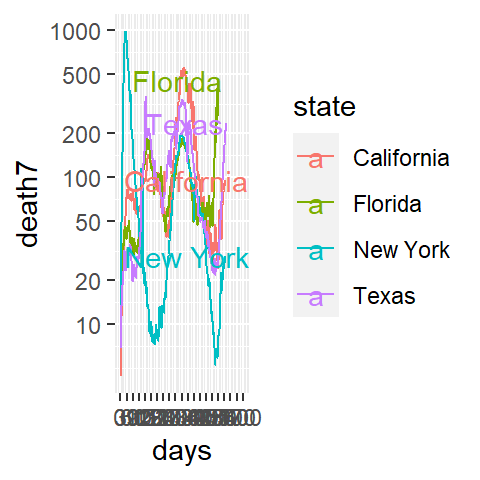

```r
p_7day <- ggplot(df_deaths_rolling_mean, aes(x=days,
                           y=death7,
                           colour=state)) +
      geom_line()

p_7day <- p_7day +
    scale_y_log10(breaks = c(1, 10, 20, 50, 100, 200, 500, 1000 )) +
    scale_x_continuous(breaks = seq(0, 600, by = 30) ,
                       limits = c(1, 600)) +
    geom_text_repel(aes(label = label),
                     nudge_x = 1,
                     na.rm = TRUE)

p_7day
```

Let us again make these plots better using some themes

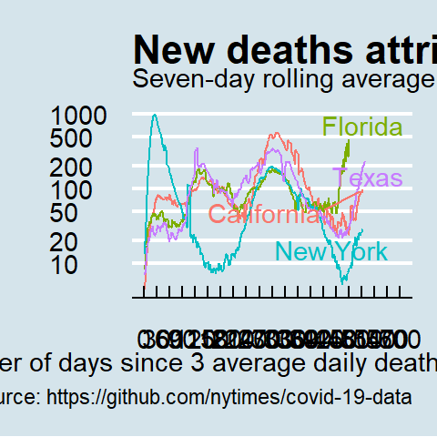

```r
p1_7day <- p_7day +
    theme_economist() +
     theme(legend.position = "none",
           axis.title.x = element_text()) +
    labs(title = "New deaths attributed to Covid-19 in NY, CA, TX, FL",
         subtitle = "Seven-day rolling average of new deaths, by number of days since 3 average daily deaths first recorded",
         x = "Number of days since 3 average daily deaths first recorded",
         y = "",
         caption = "Source: https://github.com/nytimes/covid-19-data")


p1_7day
```

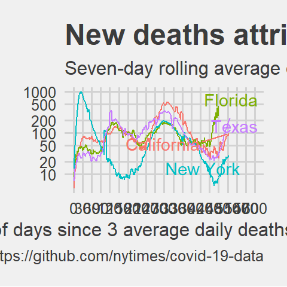

```r
p2_7day <- p_7day +
    theme_fivethirtyeight() +
    theme(legend.position = "none",
          axis.title.x = element_text()) +
    labs(title = "New deaths attributed to Covid-19 in NY, CA, TX, FL",
         subtitle = "Seven-day rolling average of new deaths, by number of days since 3 average daily deaths first recorded",
         x = "Number of days since 3 average daily deaths first recorded",
         y = "",
         caption = "Source: https://github.com/nytimes/covid-19-data")

p2_7day
```

[figure not shown]

```r
p3_7day <-  p_7day +
     theme_ft_rc()+
        theme(legend.position = "none",
          axis.title.x = element_text()) +
    labs(title = "New deaths attributed to Covid-19 in NY, CA, TX, FL",
         subtitle = "Seven-day rolling average of new deaths, by number of days since 3 average daily deaths first recorded",
         x = "Number of days since 3 average daily deaths first recorded",
         y = "",
         caption = "Source: https://github.com/nytimes/covid-19-data")

p3_7day
```

# Combining datasets with joins

We sometimes encounter the situation where we have two data sets that contain different pieces of information and we need to join these tables for further analysis. In this situation, we need to perform a join, and there are multiple different types of joins available: `left_join()`, `right_join()`, `inner_join()`, `full_join()`. These joins all differ in how they handle cases where an observation is present in only one of the two tables but missing in the other.

Two explore joins, consider the following two datasets, which contain contributions given in California to all candidates for the 2016 US presidential election and a dataframe with all zipcodes for California

```r
CA_contributions <- vroom(here::here("data","CA_contributors_2016.csv")) %>%
  janitor::clean_names()


zipcodes <- vroom(here::here("data","zip_code_database.csv")) %>%
  janitor::clean_names() %>%
  filter(state == "CA")
```

We want to join the two dataframes, as the `CA_contributions` only records the zip code and not the actual city. Try to merge `zipcodes` into `CA_contributions`, using `left_join()`. Before proceeding, think what is the `key` wou will use to join the two dataframes, have a quick look at the kinds of variables the two dataframes have.

```r
glimpse(CA_contributions)
```

```
## Rows: 1,292,843
## Columns: 4
## $ cand_nm           <chr> "Clinton, Hillary Rodham", "Clinton, Hillary Rodham"~
## $ contb_receipt_amt <dbl> 50.0, 200.0, 5.0, 48.3, 40.0, 244.3, 35.0, 100.0, 25~
## $ zip               <dbl> 94939, 93428, 92337, 95334, 93011, 95826, 90278, 902~
## $ contb_date        <date> 2016-04-26, 2016-04-20, 2016-04-02, 2016-11-21, 201~
```

```r
glimpse(zipcodes)
```

```
## Rows: 2,653
## Columns: 16
## $ zip                  <chr> "90001", "90002", "90003", "90004", "90005", "900~
## $ type                 <chr> "STANDARD", "STANDARD", "STANDARD", "STANDARD", "~
## $ primary_city         <chr> "Los Angeles", "Los Angeles", "Los Angeles", "Los~
## $ acceptable_cities    <chr> "Firestone Park, Firestone Pk", "August F. Haw, W~
## $ unacceptable_cities  <chr> NA, NA, "Broadway Manchester", NA, NA, "Pico Heig~
## $ state                <chr> "CA", "CA", "CA", "CA", "CA", "CA", "CA", "CA", "~
## $ county               <chr> "Los Angeles County", "Los Angeles County", "Los ~
## $ timezone             <chr> "America/Los_Angeles", "America/Los_Angeles", "Am~
## $ area_codes           <dbl> 2.13e+11, 2.13e+08, 3.23e+08, 2.14e+11, 3.23e+14,~
## $ latitude             <dbl> 34.0, 33.9, 34.0, 34.1, 34.0, 34.0, 34.0, 34.0, 3~
## $ longitude            <dbl> -118, -118, -118, -118, -118, -118, -118, -118, -~
## $ world_region         <chr> NA, NA, NA, NA, NA, NA, NA, NA, NA, NA, NA, NA, N~
## $ country              <chr> "US", "US", "US", "US", "US", "US", "US", "US", "~
## $ decommissioned       <dbl> 0, 0, 0, 0, 0, 0, 0, 0, 0, 0, 0, 0, 0, 0, 0, 0, 0~
## $ estimated_population <dbl> 36200, 30920, 41878, 41632, 22281, 34995, 20179, ~
## $ notes                <chr> NA, NA, NA, NA, NA, NA, NA, NA, NA, NA, NA, NA, N~
```

```r
# in CA_contributions, zip is <dbl>, a number, whereas in zipcodes it's <chr>, a character

CA_contributions <-  CA_contributions %>%
  mutate(zip = as.character(zip))
```

```r
CA_contributions_2016 <- left_join(CA_contributions, zipcodes, by="zip")
```

> `left_join()` is significantly faster than base R’s `merge()` function, so please use `left_join()`

```r
CA_contributions_2016 %>%
  group_by(primary_city, cand_nm) %>%
  summarise(total = sum(contb_receipt_amt)) %>%
  arrange(desc(total)) %>%
  head(20)
```

```
## # A tibble: 20 x 3
## # Groups:   primary_city [18]
##    primary_city      cand_nm                     total
##    <chr>             <chr>                       <dbl>
##  1 San Francisco     Clinton, Hillary Rodham 12345963.
##  2 Los Angeles       Clinton, Hillary Rodham 12022399.
##  3 Oakland           Clinton, Hillary Rodham  2955387.
##  4 Palo Alto         Clinton, Hillary Rodham  2664346.
##  5 Berkeley          Clinton, Hillary Rodham  2300980.
##  6 Beverly Hills     Clinton, Hillary Rodham  2226442.
##  7 Santa Monica      Clinton, Hillary Rodham  2134503.
##  8 San Diego         Clinton, Hillary Rodham  2094960.
##  9 San Francisco     Sanders, Bernard         1946573.
## 10 Los Angeles       Sanders, Bernard         1717273.
## 11 Sacramento        Clinton, Hillary Rodham  1623772.
## 12 Los Altos         Clinton, Hillary Rodham  1500963.
## 13 San Jose          Clinton, Hillary Rodham  1469521.
## 14 Menlo Park        Clinton, Hillary Rodham  1278295.
## 15 Pacific Palisades Clinton, Hillary Rodham  1108658.
## 16 Redwood City      Clinton, Hillary Rodham  1092511.
## 17 West Hollywood    Clinton, Hillary Rodham  1059314.
## 18 Pasadena          Clinton, Hillary Rodham  1016321.
## 19 Burlingame        Clinton, Hillary Rodham   968883.
## 20 Santa Barbara     Clinton, Hillary Rodham   868134.
```